# Detected handwritten digits with CNNs

In this assignment, we Detected handwritten digits with CNNs. MNIST dataset includes 60,000 small square 28×28 pixel grayscale images of handwritten single digits between 0 and 9. I created a simple CNN from scratch using the deep learning framework of your choice (Keras, TensorFlow) to perform classification on the MNIST dataset.

It includs the following steps: Created a base CNN model (Conv → MaxPooling → Flatten → Dropout → FC). Trained the model for 10 epochs using 10% for validation (batch_size=32, optimizer=Adam,dropout=0.5, activation=relu). Evaluated the performance of the model and reported the confusion matrix and the test accuracy. Evaluated the performance of the model with different batch sizes and different activation functions, reported the confusion matrix and the test accuracy.

Setup

Import the libs

```python
import numpy as np
import tensorflow as tf
from tensorflow import keras
import sklearn
from sklearn.metrics import confusion_matrix
import itertools
import matplotlib.pyplot as plt
```

```
2023-02-03 07:38:18.368055: I tensorflow/core/platform/cpu_feature_guard.cc:193] This TensorFlow binary is optimized with oneAPI Deep Neural Network Library (oneDNN) to use the following CPU instructions in performance-critical operations:  SSE4.1 SSE4.2 AVX AVX2 FMA
To enable them in other operations, rebuild TensorFlow with the appropriate compiler flags.
```

Prepare the data

```python
# Model / data parameters
num_classes = 10
input_shape = (28, 28, 1)

# Load the data and split it between train and test sets
(x_train, y_train), (x_test, y_test) = keras.datasets.mnist.load_data()

# Scale images to the [0, 1] range
x_train = x_train.astype("float32") / 255
x_test = x_test.astype("float32") / 255
# Make sure images have shape (28, 28, 1)
x_train = np.expand_dims(x_train, -1)
x_test = np.expand_dims(x_test, -1)
print("x_train shape:", x_train.shape)
print(x_train.shape[0], "train samples")
print(x_test.shape[0], "test samples")


# convert class vectors to binary class matrices
y_train = keras.utils.to_categorical(y_train, num_classes)
y_test = keras.utils.to_categorical(y_test, num_classes)
```

```
x_train shape: (60000, 28, 28, 1)
60000 train samples
10000 test samples
```

Build the model by adding 1 layer

```python
#build the model with 1 layer
name = '1_Layer_batch_sizes_32_relu'
model_1 = keras.Sequential(
    [
        keras.Input(shape=input_shape),
        keras.layers.Conv2D(32, kernel_size=(3, 3), activation="relu"),
        keras.layers.MaxPooling2D(pool_size=(2, 2)),
        keras.layers.Flatten(),
        keras.layers.Dropout(0.5),
        keras.layers.Dense(num_classes, activation="softmax"),
    ], name=name
)

model_1.summary()
```

```
Model: "1_Layer_batch_sizes_32_relu"
_________________________________________________________________
 Layer (type)                Output Shape              Param #
=================================================================
 conv2d (Conv2D)             (None, 26, 26, 32)        320

 max_pooling2d (MaxPooling2D  (None, 13, 13, 32)       0
 )

 flatten (Flatten)           (None, 5408)              0

 dropout (Dropout)           (None, 5408)              0

 dense (Dense)               (None, 10)                54090

=================================================================
Total params: 54,410
Trainable params: 54,410
Non-trainable params: 0
_________________________________________________________________
```

```
2023-02-03 07:38:21.649071: I tensorflow/core/platform/cpu_feature_guard.cc:193] This TensorFlow binary is optimized with oneAPI Deep Neural Network Library (oneDNN) to use the following CPU instructions in performance-critical operations:  SSE4.1 SSE4.2 AVX AVX2 FMA
To enable them in other operations, rebuild TensorFlow with the appropriate compiler flags.
2023-02-03 07:38:21.650100: I tensorflow/core/common_runtime/process_util.cc:146] Creating new thread pool with default inter op setting: 2. Tune using inter_op_parallelism_threads for best performance.
```

Train the model with 1 layer

```python
batch_size = 32
epochs = 10
#compile the model
model_1.compile(loss="categorical_crossentropy", optimizer="adam", metrics=["accuracy"])
#train the model
history_1 = model_1.fit(x_train, y_train, batch_size=batch_size, epochs=epochs, validation_split=0.1)
#save the train result
history_dict = {}
diff_batch_dict={}
diff_activate_dict={}
history_dict[model_1.name] = history_1
diff_batch_dict[model_1.name] = history_1
diff_activate_dict[model_1.name] = history_1
```

Evaluate the trained model with 1 layer

```python
#Evaluate the trained model
score = model_1.evaluate(x_test, y_test, verbose=0)
print("Test loss:", score[0])
print("Test accuracy:", score[1])
```

```
Test loss: 0.05350745841860771
Test accuracy: 0.984000027179718
```

Confusion matrix of the model with 1 layer

```
[[ 970    0    4    1    0    2    2    0    1    0]
 [   0 1131    2    2    0    0    0    0    0    0]
 [   1    2 1017    3    1    0    1    7    0    0]
 [   0    0    1 1003    0    3    0    2    1    0]
 [   0    0    2    0  969    0    1    0    2    8]
 [   2    0    0    4    0  884    2    0    0    0]
 [   7    3    0    1    3    6  936    0    2    0]
 [   0    2    9    3    0    0    0 1011    1    2]
 [   6    1    5    7    2    9    1    5  929    9]
 [   0    0    0    4    3    4    0    8    0  990]]
```

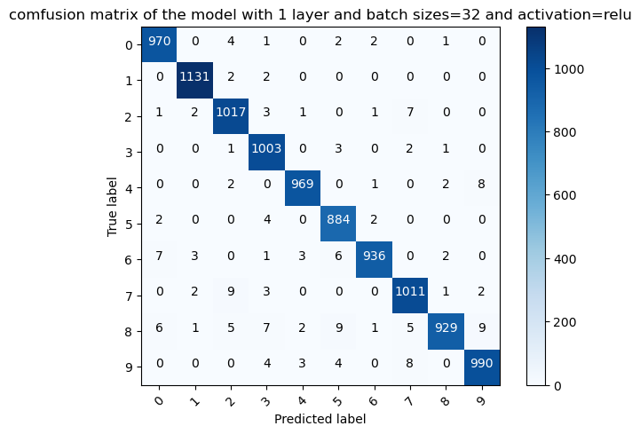

```python
# Predict the values from the validation dataset
Y_pred = model_1.predict(x_test)
# Convert predictions classes to one hot vectors
Y_pred_classes = np.argmax(Y_pred,axis = 1)
# Convert validation observations to one hot vectors
Y_true = np.argmax(y_test,axis = 1)
# compute the confusion matrix
cm = confusion_matrix(Y_true, Y_pred_classes)
print(cm)
# plot the confusion matrix
classes = range(10)
plt.imshow(cm, interpolation='nearest', cmap=plt.cm.Blues)
plt.title('comfusion matrix of the model with 1 layer and batch sizes=32 and activation=relu')
plt.colorbar()
tick_marks = np.arange(len(classes))
plt.xticks(tick_marks, classes, rotation=45)
plt.yticks(tick_marks, classes)
thresh = cm.max() / 2.
for i, j in itertools.product(range(cm.shape[0]), range(cm.shape[1])):
    plt.text(j, i, cm[i, j],
        horizontalalignment="center",
        color="white" if cm[i, j] > thresh else "black")
plt.tight_layout()
plt.ylabel('True label')
plt.xlabel('Predicted label')
plt.savefig('./confusion_matrix_1_layer_batch_sizes_32_relu.jpg')
```

Build the model by adding 2 layers

```python
#bulid the model by adding 2 layers
name = '2_Layer_batch_sizes_32_relu'
model_2 = keras.Sequential(
    [
        keras.Input(shape=input_shape),
        keras.layers.Conv2D(32, kernel_size=(3, 3), activation="relu"),
        keras.layers.MaxPooling2D(pool_size=(2, 2)),
        keras.layers.Conv2D(64, kernel_size=(3, 3), activation="relu"),
        keras.layers.MaxPooling2D(pool_size=(2, 2)),
        keras.layers.Flatten(),
        keras.layers.Dropout(0.5),
        keras.layers.Dense(num_classes, activation="softmax"),
    ],name=name
)

model_2.summary()
```

```
Model: "2_Layer_batch_sizes_32_relu"
_________________________________________________________________
 Layer (type)                Output Shape              Param #
=================================================================
 conv2d_1 (Conv2D)           (None, 26, 26, 32)        320

 max_pooling2d_1 (MaxPooling  (None, 13, 13, 32)       0
 2D)

 conv2d_2 (Conv2D)           (None, 11, 11, 64)        18496

 max_pooling2d_2 (MaxPooling  (None, 5, 5, 64)         0
 2D)

 flatten_1 (Flatten)         (None, 1600)              0

 dropout_1 (Dropout)         (None, 1600)              0

 dense_1 (Dense)             (None, 10)                16010

=================================================================
Total params: 34,826
Trainable params: 34,826
Non-trainable params: 0
_________________________________________________________________
```

Train the model with 2 layers

```python
batch_size = 32
epochs = 10
#compile the model
model_2.compile(loss="categorical_crossentropy", optimizer="adam", metrics=["accuracy"])

#train the model
history_2 = model_2.fit(x_train, y_train, batch_size=batch_size, epochs=epochs, validation_split=0.1)
history_dict[model_2.name] = history_2
```

Evaluate the trained model with 2 layers

```python
score = model_2.evaluate(x_test, y_test, verbose=0)
print("Test loss:", score[0])
print("Test accuracy:", score[1])
```

```
Test loss: 0.02553255669772625
Test accuracy: 0.9921000003814697
```

Confusion matrix of the model with 2 layers

```
[[ 974    0    1    0    0    0    2    1    2    0]
 [   0 1131    2    2    0    0    0    0    0    0]
 [   1    1 1026    0    0    0    0    4    0    0]
 [   0    0    2 1005    0    1    0    1    1    0]
 [   0    0    1    0  978    0    1    0    0    2]
 [   0    0    0    5    0  883    1    1    1    1]
 [   1    2    1    0    1    6  945    0    2    0]
 [   0    4    3    1    0    1    0 1017    1    1]
 [   1    0    1    1    0    0    0    2  965    4]
 [   0    0    0    0    2    4    0    4    2  997]]
```

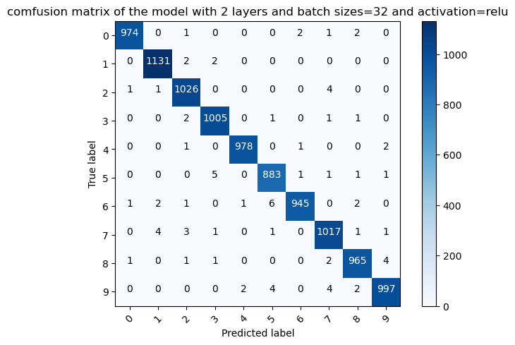

```python
# Predict the values from the validation dataset
Y_pred = model_2.predict(x_test)
# Convert predictions classes to one hot vectors
Y_pred_classes = np.argmax(Y_pred,axis = 1)
# Convert validation observations to one hot vectors
Y_true = np.argmax(y_test,axis = 1)
# compute the confusion matrix
cm = confusion_matrix(Y_true, Y_pred_classes)
print(cm)
# plot the confusion matrix
classes = range(10)
plt.imshow(cm, interpolation='nearest', cmap=plt.cm.Blues)
plt.title('comfusion matrix of the model with 2 layers and batch sizes=32 and activation=relu')
plt.colorbar()
tick_marks = np.arange(len(classes))
plt.xticks(tick_marks, classes, rotation=45)
plt.yticks(tick_marks, classes)
thresh = cm.max() / 2.
for i, j in itertools.product(range(cm.shape[0]), range(cm.shape[1])):
    plt.text(j, i, cm[i, j],
        horizontalalignment="center",
        color="white" if cm[i, j] > thresh else "black")
plt.tight_layout()
plt.ylabel('True label')
plt.xlabel('Predicted label')
plt.savefig('./confusion_matrix_2_layer_batch_size_32_relu.jpg')
```

Build the model by adding 3 layers

```python
name='3_Layer_batch_sizes_32_relu'
model_3 = keras.Sequential(
    [
        keras.Input(shape=input_shape),
        keras.layers.Conv2D(32, kernel_size=(3, 3), activation="relu"),
        keras.layers.MaxPooling2D(pool_size=(2, 2)),
        keras.layers.Conv2D(64, kernel_size=(3, 3), activation="relu"),
        keras.layers.MaxPooling2D(pool_size=(2, 2)),
        keras.layers.Conv2D(128, kernel_size=(3,3), activation="relu"),
        keras.layers.MaxPooling2D(pool_size=(2,2)),
        keras.layers.Flatten(),
        keras.layers.Dropout(0.5),
        keras.layers.Dense(num_classes, activation="softmax"),
    ], name=name
)

model_3.summary()
```

```
Model: "3_Layer_batch_sizes_32_relu"
_________________________________________________________________
 Layer (type)                Output Shape              Param #
=================================================================
 conv2d_3 (Conv2D)           (None, 26, 26, 32)        320

 max_pooling2d_3 (MaxPooling  (None, 13, 13, 32)       0
 2D)

 conv2d_4 (Conv2D)           (None, 11, 11, 64)        18496

 max_pooling2d_4 (MaxPooling  (None, 5, 5, 64)         0
 2D)

 conv2d_5 (Conv2D)           (None, 3, 3, 128)         73856

 max_pooling2d_5 (MaxPooling  (None, 1, 1, 128)        0
 2D)

 flatten_2 (Flatten)         (None, 128)               0

 dropout_2 (Dropout)         (None, 128)               0

 dense_2 (Dense)             (None, 10)                1290

=================================================================
Total params: 93,962
Trainable params: 93,962
Non-trainable params: 0
_________________________________________________________________
```

Train the model with 3 layers

```python
atch_size = 32
epochs = 10

model_3.compile(loss="categorical_crossentropy", optimizer="adam", metrics=["accuracy"])

history_3 = model_3.fit(x_train, y_train, batch_size=batch_size, epochs=epochs, validation_split=0.1)
history_dict[model_3.name] = history_3
```

Evaluate the trained model with 3 layers

```python
score = model_3.evaluate(x_test, y_test, verbose=0)
print("Test loss:", score[0])
print("Test accuracy:", score[1])
```

```
Test loss: 0.0416208878159523
Test accuracy: 0.989799976348877
```

Confusion matrix of the model with 3 layers

```
[[ 972    1    2    0    0    0    2    2    0    1]
 [   0 1131    1    1    0    0    1    0    0    1]
 [   2    0 1018    3    0    0    0    9    0    0]
 [   0    1    2 1003    0    2    0    1    1    0]
 [   0    0    0    0  977    0    0    0    1    4]
 [   1    1    0    3    0  885    1    1    0    0]
 [   3    2    0    0    2    5  945    0    1    0]
 [   0    5    8    0    0    1    0 1008    3    3]
 [   0    0    0    1    2    1    0    1  968    1]
 [   3    1    0    0    4    4    0    3    3  991]]
```

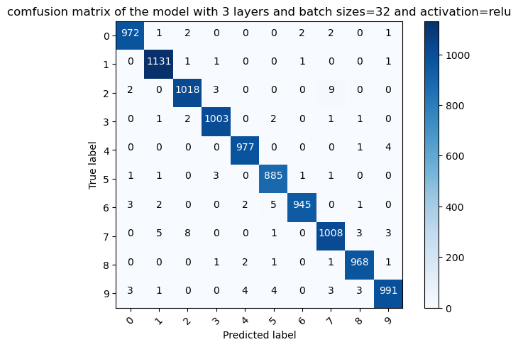

```python
# Predict the values from the validation dataset
Y_pred = model_3.predict(x_test)
# Convert predictions classes to one hot vectors
Y_pred_classes = np.argmax(Y_pred,axis = 1)
# Convert validation observations to one hot vectors
Y_true = np.argmax(y_test,axis = 1)
# compute the confusion matrix
cm = confusion_matrix(Y_true, Y_pred_classes)
print(cm)
# plot the confusion matrix
classes = range(10)
plt.imshow(cm, interpolation='nearest', cmap=plt.cm.Blues)
plt.title('comfusion matrix of the model with 3 layers and batch sizes=32 and activation=relu')
plt.colorbar()
tick_marks = np.arange(len(classes))
plt.xticks(tick_marks, classes, rotation=45)
plt.yticks(tick_marks, classes)
thresh = cm.max() / 2.
for i, j in itertools.product(range(cm.shape[0]), range(cm.shape[1])):
    plt.text(j, i, cm[i, j],
        horizontalalignment="center",
        color="white" if cm[i, j] > thresh else "black")
plt.tight_layout()
plt.ylabel('True label')
plt.xlabel('Predicted label')
plt.savefig('./confusion_matrix_3_layer_batch_sizes_32_relu.jpg')
```

Try the model with 1 layer and using different batch sizes(64,128,256)

The model with 1 layer and batch sizes=64

```
Model: "1_Layer_batch_sizes_64_relu"
_________________________________________________________________
 Layer (type)                Output Shape              Param #
=================================================================
 conv2d_6 (Conv2D)           (None, 26, 26, 32)        320

 max_pooling2d_6 (MaxPooling  (None, 13, 13, 32)       0
 2D)

 flatten_3 (Flatten)         (None, 5408)              0

 dropout_3 (Dropout)         (None, 5408)              0

 dense_3 (Dense)             (None, 10)                54090

=================================================================
Total params: 54,410
Trainable params: 54,410
Non-trainable params: 0
_________________________________________________________________
Test loss: 0.056768596172332764
Test accuracy: 0.9815000295639038
[[ 974    0    2    1    0    0    1    0    2    0]
 [   0 1124    3    3    0    0    2    1    2    0]
 [   3    2 1011    3    1    0    1    5    6    0]
 [   0    0    1 1003    0    2    0    0    4    0]
 [   1    0    2    1  965    0    2    0    3    8]
 [   3    0    2   13    0  867    4    0    3    0]
 [   7    2    0    1    1    2  940    0    5    0]
 [   1    2   11    7    0    0    0  999    3    5]
 [   6    0    2    1    1    1    0    2  957    4]
 [   6    1    0    8    5    2    0    5    7  975]]
```

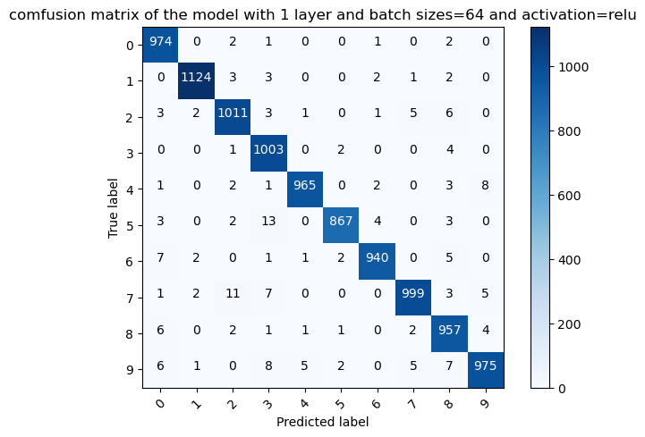

```python
#build the model with 1 layer and batch size=64 and activation=relu
name = '1_Layer_batch_sizes_64_relu'
model_1_64 = keras.Sequential(
    [
        keras.Input(shape=input_shape),
        keras.layers.Conv2D(32, kernel_size=(3, 3), activation="relu"),
        keras.layers.MaxPooling2D(pool_size=(2, 2)),
        keras.layers.Flatten(),
        keras.layers.Dropout(0.5),
        keras.layers.Dense(num_classes, activation="softmax"),
    ], name=name
)

model_1_64.summary()

batch_size = 64
epochs = 10
#compile the model
model_1_64.compile(loss="categorical_crossentropy", optimizer="adam", metrics=["accuracy"])
#train the model
history_1_64 = model_1_64.fit(x_train, y_train, batch_size=batch_size, epochs=epochs, validation_split=0.1)
#save the train result
diff_batch_dict[model_1_64.name] = history_1_64

#Evaluate the trained model
score = model_1_64.evaluate(x_test, y_test, verbose=0)
print("Test loss:", score[0])
print("Test accuracy:", score[1])

# Predict the values from the validation dataset
Y_pred = model_1_64.predict(x_test)
# Convert predictions classes to one hot vectors
Y_pred_classes = np.argmax(Y_pred,axis = 1)
# Convert validation observations to one hot vectors
Y_true = np.argmax(y_test,axis = 1)
# compute the confusion matrix
cm = confusion_matrix(Y_true, Y_pred_classes)
print(cm)
# plot the confusion matrix
classes = range(10)
plt.imshow(cm, interpolation='nearest', cmap=plt.cm.Blues)
plt.title('comfusion matrix of the model with 1 layer and batch sizes=64 and activation=relu')
plt.colorbar()
tick_marks = np.arange(len(classes))
plt.xticks(tick_marks, classes, rotation=45)
plt.yticks(tick_marks, classes)
thresh = cm.max() / 2.
for i, j in itertools.product(range(cm.shape[0]), range(cm.shape[1])):
    plt.text(j, i, cm[i, j],
        horizontalalignment="center",
        color="white" if cm[i, j] > thresh else "black")
plt.tight_layout()
plt.ylabel('True label')
plt.xlabel('Predicted label')
plt.savefig('./confusion_matrix_1_layer_batch_size_64_relu.jpg')
```

The model with 1 layer and batch sizes=128

```
Model: "1_Layer_batch_sizes_128_relu"
_________________________________________________________________
 Layer (type)                Output Shape              Param #
=================================================================
 conv2d_7 (Conv2D)           (None, 26, 26, 32)        320

 max_pooling2d_7 (MaxPooling  (None, 13, 13, 32)       0
 2D)

 flatten_4 (Flatten)         (None, 5408)              0

 dropout_4 (Dropout)         (None, 5408)              0

 dense_4 (Dense)             (None, 10)                54090

=================================================================
Total params: 54,410
Trainable params: 54,410
Non-trainable params: 0
_________________________________________________________________
Test loss: 0.055423203855752945
Test accuracy: 0.9811999797821045
[[ 974    0    1    1    0    1    1    0    2    0]
 [   0 1127    2    2    1    0    1    1    1    0]
 [   3    6 1006    2    3    0    0    9    3    0]
 [   0    0    1  997    0    8    0    3    1    0]
 [   1    0    0    0  971    0    3    0    2    5]
 [   2    0    0    4    0  882    3    0    1    0]
 [   7    3    0    1    2    3  941    0    1    0]
 [   1    4   10    3    0    1    0 1005    2    2]
 [   7    0    4    6    3    2    1    7  937    7]
 [   4    5    0    5    9    4    0    8    2  972]]
```

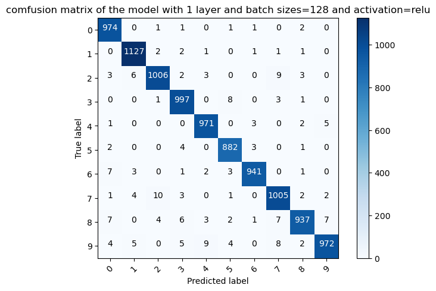

```python
#build the model with 1 layer and batch size=128
name = '1_Layer_batch_sizes_128_relu'
model_1_128 = keras.Sequential(
    [
        keras.Input(shape=input_shape),
        keras.layers.Conv2D(32, kernel_size=(3, 3), activation="relu"),
        keras.layers.MaxPooling2D(pool_size=(2, 2)),
        keras.layers.Flatten(),
        keras.layers.Dropout(0.5),
        keras.layers.Dense(num_classes, activation="softmax"),
    ], name=name
)

model_1_128.summary()

batch_size = 128
epochs = 10
#compile the model
model_1_128.compile(loss="categorical_crossentropy", optimizer="adam", metrics=["accuracy"])
#train the model
history_1_128 = model_1_128.fit(x_train, y_train, batch_size=batch_size, epochs=epochs, validation_split=0.1)
#save the train result
diff_batch_dict[model_1_128.name] = history_1_128

#Evaluate the trained model
score = model_1_128.evaluate(x_test, y_test, verbose=0)
print("Test loss:", score[0])
print("Test accuracy:", score[1])

# Predict the values from the validation dataset
Y_pred = model_1_128.predict(x_test)
# Convert predictions classes to one hot vectors
Y_pred_classes = np.argmax(Y_pred,axis = 1)
# Convert validation observations to one hot vectors
Y_true = np.argmax(y_test,axis = 1)
# compute the confusion matrix
cm = confusion_matrix(Y_true, Y_pred_classes)
print(cm)
# plot the confusion matrix
classes = range(10)
plt.imshow(cm, interpolation='nearest', cmap=plt.cm.Blues)
plt.title('comfusion matrix of the model with 1 layer and batch sizes=128 and activation=relu')
plt.colorbar()
tick_marks = np.arange(len(classes))
plt.xticks(tick_marks, classes, rotation=45)
plt.yticks(tick_marks, classes)
thresh = cm.max() / 2.
for i, j in itertools.product(range(cm.shape[0]), range(cm.shape[1])):
    plt.text(j, i, cm[i, j],
        horizontalalignment="center",
        color="white" if cm[i, j] > thresh else "black")
plt.tight_layout()
plt.ylabel('True label')
plt.xlabel('Predicted label')
plt.savefig('./confusion_matrix_1_layer_batch_size_128_relu.jpg')
```

The model with 1 layer and batch sizes=256

```
Model: "1_Layer_batch_sizes_256_relu"
_________________________________________________________________
 Layer (type)                Output Shape              Param #
=================================================================
 conv2d_8 (Conv2D)           (None, 26, 26, 32)        320

 max_pooling2d_8 (MaxPooling  (None, 13, 13, 32)       0
 2D)

 flatten_5 (Flatten)         (None, 5408)              0

 dropout_5 (Dropout)         (None, 5408)              0

 dense_5 (Dense)             (None, 10)                54090

=================================================================
Total params: 54,410
Trainable params: 54,410
Non-trainable params: 0
_________________________________________________________________
Test loss: 0.06543399393558502
Test accuracy: 0.9790999889373779
[[ 972    0    1    0    0    0    2    3    2    0]
 [   0 1128    3    0    0    0    3    0    1    0]
 [   4    3 1005    3    4    0    1    8    4    0]
 [   0    0    3  986    0    9    0    5    4    3]
 [   1    1    1    0  968    0    2    0    2    7]
 [   2    0    0    3    0  879    4    1    2    1]
 [   8    3    0    0    2    3  937    1    4    0]
 [   1    3   11    2    1    0    0 1005    3    2]
 [   6    0    5    3    3    1    0    6  942    8]
 [   4    5    1    3   10    1    0   13    3  969]]
```

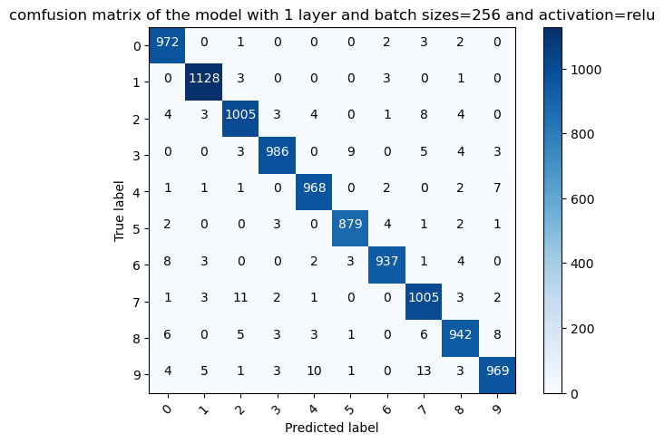

```python
#build the model with 1 layer and batch size=256
name = '1_Layer_batch_sizes_256_relu'
model_1_256 = keras.Sequential(
    [
        keras.Input(shape=input_shape),
        keras.layers.Conv2D(32, kernel_size=(3, 3), activation="relu"),
        keras.layers.MaxPooling2D(pool_size=(2, 2)),
        keras.layers.Flatten(),
        keras.layers.Dropout(0.5),
        keras.layers.Dense(num_classes, activation="softmax"),
    ], name=name
)

model_1_256.summary()

batch_size = 256
epochs = 10
#compile the model
model_1_256.compile(loss="categorical_crossentropy", optimizer="adam", metrics=["accuracy"])
#train the model
history_1_256 = model_1_256.fit(x_train, y_train, batch_size=batch_size, epochs=epochs, validation_split=0.1)
#save the train result
diff_batch_dict[model_1_256.name] = history_1_256

#Evaluate the trained model
score = model_1_256.evaluate(x_test, y_test, verbose=0)
print("Test loss:", score[0])
print("Test accuracy:", score[1])

# Predict the values from the validation dataset
Y_pred = model_1_256.predict(x_test)
# Convert predictions classes to one hot vectors
Y_pred_classes = np.argmax(Y_pred,axis = 1)
# Convert validation observations to one hot vectors
Y_true = np.argmax(y_test,axis = 1)
# compute the confusion matrix
cm = confusion_matrix(Y_true, Y_pred_classes)
print(cm)
# plot the confusion matrix
classes = range(10)
plt.imshow(cm, interpolation='nearest', cmap=plt.cm.Blues)
plt.title('comfusion matrix of the model with 1 layer and batch sizes=256 and activation=relu')
plt.colorbar()
tick_marks = np.arange(len(classes))
plt.xticks(tick_marks, classes, rotation=45)
plt.yticks(tick_marks, classes)
thresh = cm.max() / 2.
for i, j in itertools.product(range(cm.shape[0]), range(cm.shape[1])):
    plt.text(j, i, cm[i, j],
        horizontalalignment="center",
        color="white" if cm[i, j] > thresh else "black")
plt.tight_layout()
plt.ylabel('True label')
plt.xlabel('Predicted label')
plt.savefig('./confusion_matrix_1_layer_batch_size_256_relu.jpg')
```

Try the model with 1 layer and batch sizes=32 and using different activation functions('selu','elu')

The model with 1 layer and batch sizes=32 and activation function='selu'

```
Model: "1_Layer_batch_sizes_32_selu"
_________________________________________________________________
 Layer (type)                Output Shape              Param #
=================================================================
 conv2d_9 (Conv2D)           (None, 26, 26, 32)        320

 max_pooling2d_9 (MaxPooling  (None, 13, 13, 32)       0
 2D)

 flatten_6 (Flatten)         (None, 5408)              0

 dropout_6 (Dropout)         (None, 5408)              0

 dense_6 (Dense)             (None, 10)                54090

=================================================================
Total params: 54,410
Trainable params: 54,410
Non-trainable params: 0
_________________________________________________________________
Test loss: 0.08208470791578293
Test accuracy: 0.9739999771118164
[[ 969    0    3    1    0    0    3    4    0    0]
 [   2 1124    1    5    0    0    1    1    1    0]
 [   4    2  994   10    5    0    2    9    5    1]
 [   0    0    2  998    0    4    0    4    2    0]
 [   1    0    4    0  970    0    0    1    2    4]
 [   3    1    2   10    0  867    6    1    2    0]
 [   8    3    1    0    6    3  932    1    4    0]
 [   0    1   12   13    4    0    0  995    2    1]
 [   8    0    9   13    5    4    0    7  925    3]
 [   5    1    1    8   12    5    0    9    2  966]]
```

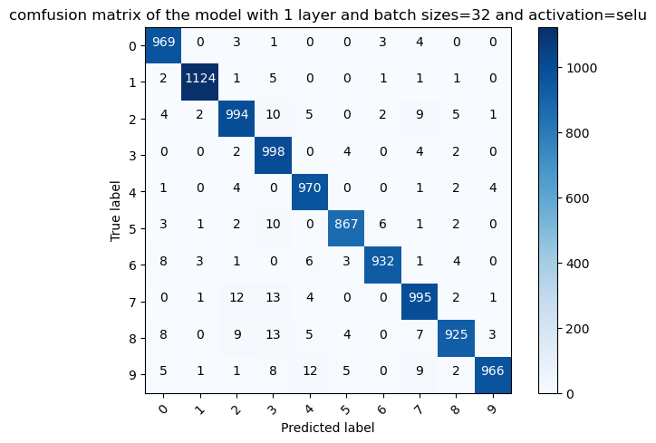

```python
#build the model with 1 layer and batch size=32 and activation function='selu'
name = '1_Layer_batch_sizes_32_selu'
model_1_32_selu = keras.Sequential(
    [
        keras.Input(shape=input_shape),
        keras.layers.Conv2D(32, kernel_size=(3, 3), activation="selu"),
        keras.layers.MaxPooling2D(pool_size=(2, 2)),
        keras.layers.Flatten(),
        keras.layers.Dropout(0.5),
        keras.layers.Dense(num_classes, activation="softmax"),
    ], name=name
)

model_1_32_selu.summary()

batch_size = 32
epochs = 10
#compile the model
model_1_32_selu.compile(loss="categorical_crossentropy", optimizer="adam", metrics=["accuracy"])
#train the model
history_1_32_selu = model_1_32_selu.fit(x_train, y_train, batch_size=batch_size, epochs=epochs, validation_split=0.1)
#save the train result
diff_activate_dict[model_1_32_selu.name] = history_1_32_selu

#Evaluate the trained model
score = model_1_32_selu.evaluate(x_test, y_test, verbose=0)
print("Test loss:", score[0])
print("Test accuracy:", score[1])

# Predict the values from the validation dataset
Y_pred = model_1_32_selu.predict(x_test)
# Convert predictions classes to one hot vectors
Y_pred_classes = np.argmax(Y_pred,axis = 1)
# Convert validation observations to one hot vectors
Y_true = np.argmax(y_test,axis = 1)
# compute the confusion matrix
cm = confusion_matrix(Y_true, Y_pred_classes)
print(cm)
# plot the confusion matrix
classes = range(10)
plt.imshow(cm, interpolation='nearest', cmap=plt.cm.Blues)
plt.title('comfusion matrix of the model with 1 layer and batch sizes=32 and activation=selu')
plt.colorbar()
tick_marks = np.arange(len(classes))
plt.xticks(tick_marks, classes, rotation=45)
plt.yticks(tick_marks, classes)
thresh = cm.max() / 2.
for i, j in itertools.product(range(cm.shape[0]), range(cm.shape[1])):
    plt.text(j, i, cm[i, j],
        horizontalalignment="center",
        color="white" if cm[i, j] > thresh else "black")
plt.tight_layout()
plt.ylabel('True label')
plt.xlabel('Predicted label')
plt.savefig('./confusion_matrix_1_layer_batch_size_32_selu.jpg')
```

The model with 1 layer and batch sizes=32 and activation function='elu'

```
Model: "1_Layer_batch_sizes_32_elu"
_________________________________________________________________
 Layer (type)                Output Shape              Param #
=================================================================
 conv2d_10 (Conv2D)          (None, 26, 26, 32)        320

 max_pooling2d_10 (MaxPoolin  (None, 13, 13, 32)       0
 g2D)

 flatten_7 (Flatten)         (None, 5408)              0

 dropout_7 (Dropout)         (None, 5408)              0

 dense_7 (Dense)             (None, 10)                54090

=================================================================
Total params: 54,410
Trainable params: 54,410
Non-trainable params: 0
_________________________________________________________________
Test loss: 0.06536227464675903
Test accuracy: 0.9797000288963318
[[ 971    0    2    0    0    1    3    1    2    0]
 [   0 1126    4    1    0    1    1    1    1    0]
 [   3    2 1003    1    4    0    3    7    8    1]
 [   0    0    3  992    0    7    0    4    4    0]
 [   1    1    1    0  967    0    3    1    2    6]
 [   2    0    3    3    0  879    3    0    2    0]
 [   6    1    2    0    2    2  943    0    2    0]
 [   0    2   12    3    1    0    0 1006    3    1]
 [   5    0    5    2    1    2    2    4  952    1]
 [   5    4    0    5   11    6    0   11    9  958]]
```

[figure not shown]

```python
#build the model with 1 layer and batch size=32 and activation function='selu'
name = '1_Layer_batch_sizes_32_elu'
model_1_32_elu = keras.Sequential(
    [
        keras.Input(shape=input_shape),
        keras.layers.Conv2D(32, kernel_size=(3, 3), activation="elu"),
        keras.layers.MaxPooling2D(pool_size=(2, 2)),
        keras.layers.Flatten(),
        keras.layers.Dropout(0.5),
        keras.layers.Dense(num_classes, activation="softmax"),
    ], name=name
)

model_1_32_elu.summary()

batch_size = 32
epochs = 10
#compile the model
model_1_32_elu.compile(loss="categorical_crossentropy", optimizer="adam", metrics=["accuracy"])
#train the model
history_1_32_elu = model_1_32_elu.fit(x_train, y_train, batch_size=batch_size, epochs=epochs, validation_split=0.1)
#save the train result
diff_activate_dict[model_1_32_elu.name] = history_1_32_elu

#Evaluate the trained model
score = model_1_32_elu.evaluate(x_test, y_test, verbose=0)
print("Test loss:", score[0])
print("Test accuracy:", score[1])

# Predict the values from the validation dataset
Y_pred = model_1_32_elu.predict(x_test)
# Convert predictions classes to one hot vectors
Y_pred_classes = np.argmax(Y_pred,axis = 1)
# Convert validation observations to one hot vectors
Y_true = np.argmax(y_test,axis = 1)
# compute the confusion matrix
cm = confusion_matrix(Y_true, Y_pred_classes)
print(cm)
# plot the confusion matrix
classes = range(10)
plt.imshow(cm, interpolation='nearest', cmap=plt.cm.Blues)
plt.title('comfusion matrix of the model with 1 layer and batch sizes=32 and activation=selu')
plt.colorbar()
tick_marks = np.arange(len(classes))
plt.xticks(tick_marks, classes, rotation=45)
plt.yticks(tick_marks, classes)
thresh = cm.max() / 2.
for i, j in itertools.product(range(cm.shape[0]), range(cm.shape[1])):
    plt.text(j, i, cm[i, j],
        horizontalalignment="center",
        color="white" if cm[i, j] > thresh else "black")
plt.tight_layout()
plt.ylabel('True label')
plt.xlabel('Predicted label')
plt.savefig('./confusion_matrix_1_layer_batch_size_32_elu.jpg')
```

Summery

Plot the accuracy and loss of the model with different layers

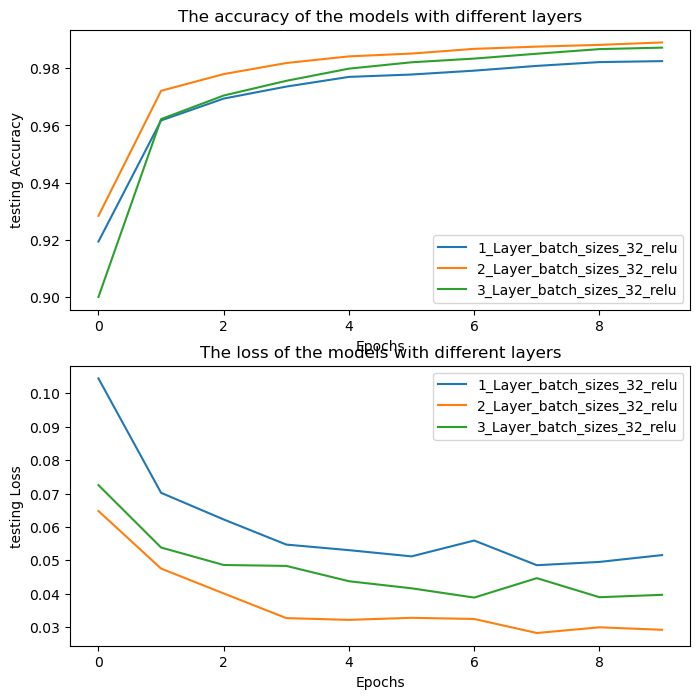

```python
#Plot the accuracy and loss of the model with different layers
fig,(ax1,ax2)=plt.subplots(2,figsize=(8,8))
for history in history_dict:
    val_acc = history_dict[history].history['accuracy']
    val_loss = history_dict[history].history['val_loss']
    ax1.plot(val_acc, label=history)
    ax2.plot(val_loss, label=history)
ax1.set_ylabel('testing Accuracy')
ax2.set_ylabel('testing Loss')
ax1.set_xlabel('Epochs')
ax2.set_xlabel('Epochs')
ax1.set_title("The accuracy of the models with different layers")
ax2.set_title("The loss of the models with different layers")
ax1.legend()
ax2.legend()
plt.show()
```

Above figure showed that the model with 2 layers with the same batch sizes and the activate function had the best accuracy.

Plot the accuracy and loss of the model with the same layers but different batch sizes

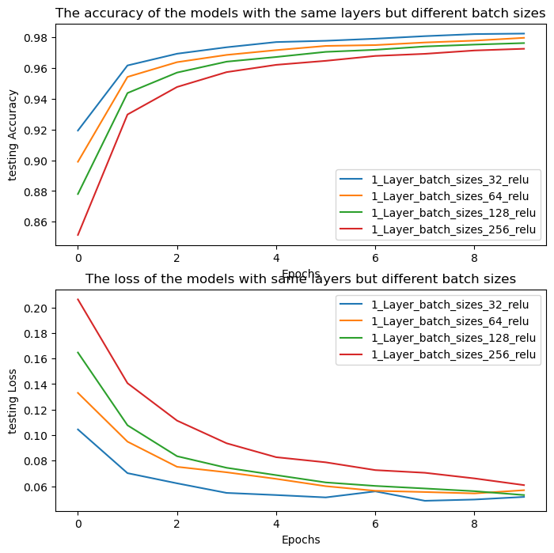

```python
#Plot the accuracy and loss of the model with the same layers but different batch sizes
fig,(ax1,ax2)=plt.subplots(2,figsize=(8,8))
for history in diff_batch_dict:
    val_acc = diff_batch_dict[history].history['accuracy']
    val_loss = diff_batch_dict[history].history['val_loss']
    ax1.plot(val_acc, label=history)
    ax2.plot(val_loss, label=history)
ax1.set_ylabel('testing Accuracy')
ax2.set_ylabel('testing Loss')
ax1.set_xlabel('Epochs')
ax2.set_xlabel('Epochs')
ax1.set_title("The accuracy of the models with the same layers but different batch sizes")
ax2.set_title("The loss of the models with same layers but different batch sizes")
ax1.legend()
ax2.legend()
plt.show()
```

Above figure showed that the model with 1 layer and batch sizes is 32 and the activate function is relu had the best accuracy.

Plot the accuracy and loss of the model with the same layers and same batch sizes but different activation functions

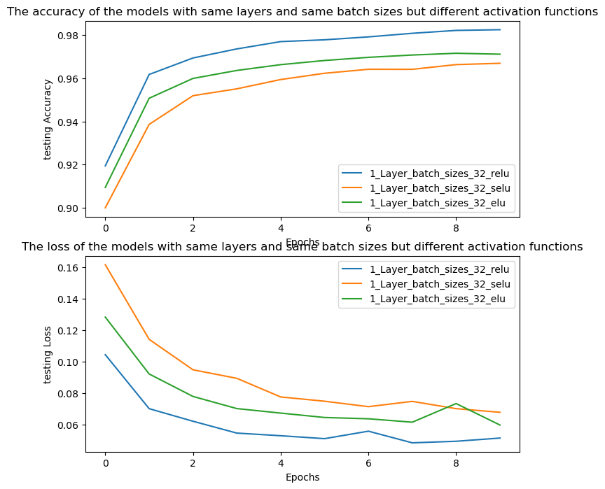

```python
#Plot the accuracy and loss of the model with the same layers and same batch sizes but different activation functions
fig,(ax1,ax2)=plt.subplots(2,figsize=(8,8))
for history in diff_activate_dict:
    val_acc = diff_activate_dict[history].history['accuracy']
    val_loss = diff_activate_dict[history].history['val_loss']
    ax1.plot(val_acc, label=history)
    ax2.plot(val_loss, label=history)
ax1.set_ylabel('testing Accuracy')
ax2.set_ylabel('testing Loss')
ax1.set_xlabel('Epochs')
ax2.set_xlabel('Epochs')
ax1.set_title("The accuracy of the models with same layers and same batch sizes but different activation functions")
ax2.set_title("The loss of the models with same layers and same batch sizes but different activation functions")
ax1.legend()
ax2.legend()
plt.show()
```

Above figure showed that the model with the same layers and same batch sizes but the activation function is relu had the best accuracy.

The difference between epoch and batch is:

The batch size is a number of samples processed before the model is updated. The size of a batch must be more than or equal to one and less than or equal to the number of samples in the training dataset.

The number of epochs is the number of complete passes through the training dataset. The number of epochs can be set to an integer value between one and infinity.

Max pooling is a pooling operation that selects the maximum element from the region of the feature map covered by the filter. Thus, the output after the max-pooling layer would be a feature map containing the most prominent features of the previous feature map.